# Month Expense Analysis

David

2023-10-26

### Data Preprocessing

```r
data = read.csv('Oct_data.csv')
head(data)
```

```
##   Posted.Date                                  Payee Amount              type
## 1   24-Oct-23    SP DYLANS CANDY BAR 121-26202700 NY -14.16     food, outside
## 2   24-Oct-23 AMZN Mktp US*P64J06W83 Amzn.com/billWA -21.76         essential
## 3   24-Oct-23 AMZN Mktp US*KT9EA0T33 Amzn.com/billWA -62.05          shopping
## 4   24-Oct-23   STATUE LIBERTY CROWNCAFE NEW YORK NY -21.00     food, outside
## 5   24-Oct-23             Uniqlo USA LLC New York NY -29.90 clothes, shopping
## 6   23-Oct-23          TRADER JOE S #545 NEW YORK NY -23.00        cook, food
##   isTransportation           Address
## 1                0  121-26202700  NY
## 2                0 Amzn.com/bill WA
## 3                0 Amzn.com/bill WA
## 4                0 NEW YORK      NY
## 5                0 New York      NY
## 6                0 NEW YORK      NY
```

```r
# unique type
unique(data$type)
```

```
## [1] "food, outside"     "essential"         "shopping"
## [4] "clothes, shopping" "cook, food"        ""
## [7] "entertainment"     "transportation"
```

```r
# there are some empty cells in `type` column
data['type'][data['isTransportation']==1]
```

```
##  [1] ""               ""               ""               ""
##  [5] ""               ""               ""               ""
##  [9] ""               ""               "transportation" "transportation"
## [13] "transportation" "transportation" "transportation" "transportation"
## [17] "transportation" "transportation" "transportation" ""
## [21] ""               ""               ""               ""
## [25] ""               ""               ""               ""
## [29] ""               ""               ""               ""
## [33] ""               ""               ""               ""
```

```r
# fill empty cell in `type` column by `isTransportation`
data['type'][data['isTransportation']==1] = "Transportation"

# check if there is empty cell in `type` column
length(data['type'][data['type']==''])
```

```
## [1] 0
```

```r
# drop `isTranspotation` and `Address`
df = subset(data, select = -c(isTransportation, Address))

# rename column
names(df) = c('Date', 'Payee', 'Amount', 'Type')

# convert char to date format
df$Date <- as.Date(df$Date, format = "%d-%b-%y")

# reorder rows ascending date
df <- df[order(df$Date), ]

# convert amount positive value
df$Amount <- -df$Amount

# unique type
unique(df$Type)
```

```
## [1] "essential"         "Transportation"    "shopping"
## [4] "food, outside"     "cook, food"        "transportation"
## [7] "entertainment"     "clothes, shopping"
```

```r
# create subcategory by dividing 'type' + captialize the first char of type
df$Subtype = ifelse(grepl('outside', df$Type) | grepl('cook', df$Type),
                    ifelse(grepl('outside', df$Type), 'outside', 'cook'),
                    "None")
df$Type = ifelse(grepl('food', df$Type), 'food', df$Type)
df$Type = str_to_title(df$Type)
df$Subtype = str_to_title(df$Subtype)

# check the unique type
unique(df$Type)
```

```
## [1] "Essential"         "Transportation"    "Shopping"
## [4] "Food"              "Entertainment"     "Clothes, Shopping"
```

```r
# turn "Clothes, Shopping" into one type and one subtype
df$Subtype = ifelse(grepl('Clothes', df$Type),
                    'Clothes',
                    df$Subtype)
df$Type = ifelse(grepl('Clothes', df$Type), 'Shopping', df$Type)

head(df)
```

```
##           Date                                  Payee Amount           Type
## 110 2023-09-25     CVS PHARMACY #11088 JERSEY CITY NJ  23.23      Essential
## 111 2023-09-25     CVS PHARMACY #11088 JERSEY CITY NJ  22.72      Essential
## 112 2023-09-25             MTA*NYCT PAYGO NEW YORK NY   2.90 Transportation
## 113 2023-09-25 AMZN Mktp US*T11VG2812 Amzn.com/billWA  15.24       Shopping
## 114 2023-09-25             MTA*NYCT PAYGO NEW YORK NY   2.90 Transportation
## 106 2023-09-26                 SQ *BOSINO New York NY  45.68           Food
##     Subtype
## 110    None
## 111    None
## 112    None
## 113    None
## 114    None
## 106 Outside
```

### Visualization

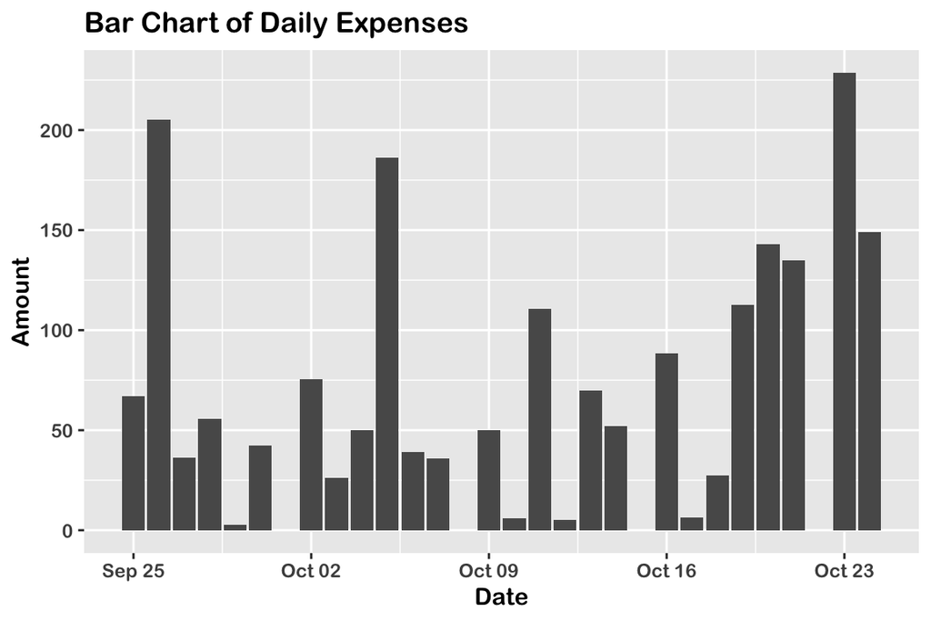

```r
# Date vs Amount

# Bar Chart by Date
bar = ggplot(df, aes(Date, Amount)) +
  geom_col() +
  labs(title = "Bar Chart of Daily Expenses") +
  theme(text = element_text(family = "Arial Rounded MT Bold"))
bar
```

The bar chart looks like multimodal, meaning I spent significant amount of money on some dates. So, I draw a line to distinguish whether the amount is over $150

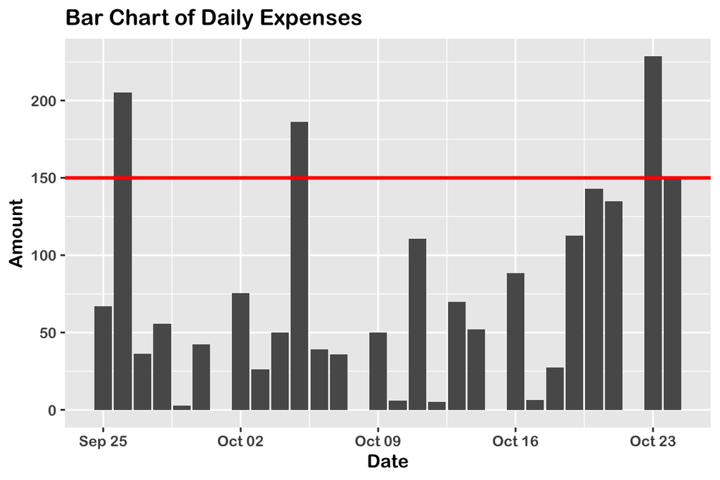

```r
bar +
  geom_hline(yintercept = 150, linetype = "solid", color = "red", size = 1)
```

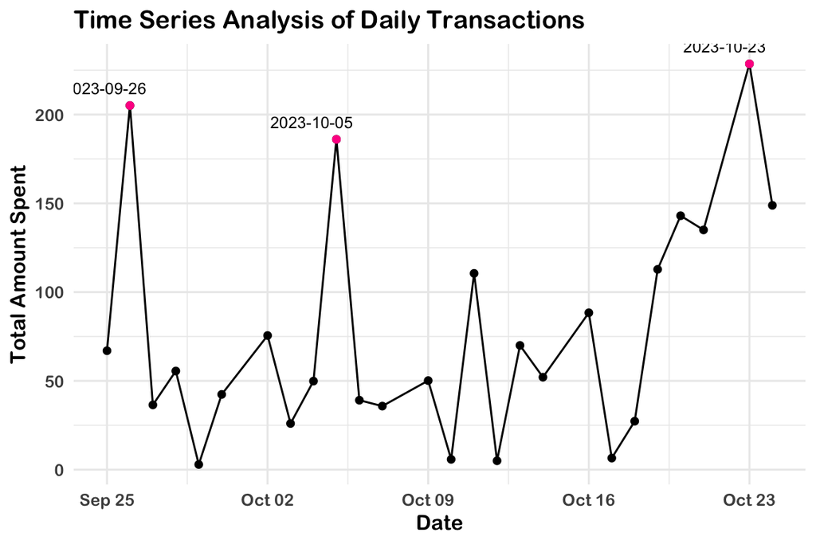

```r
# group by date
groupby_date <- df %>%
  group_by(Date) %>%
  summarise(Total_Amount = sum(Amount))

# time series plot
time_series <- ggplot(groupby_date, aes(x = Date, y = Total_Amount)) +
  geom_line() +
  geom_point() +
  ggtitle("Time Series Analysis of Daily Transactions") +
  xlab("Date") +
  ylab("Total Amount Spent") +
  theme_minimal()

top_five_day <- groupby_date %>%
  arrange(desc(Total_Amount)) %>%
  head(3)

time_series +
  geom_point(data = top_five_day, aes(Date, Total_Amount), color = "deeppink") +
  geom_text(data = top_five_day, aes(label = as.character(Date)), vjust = -1, hjust = 0.8, size = 3) +
  theme(text = element_text(family = "Arial Rounded MT Bold"))
```

I will dive into these days to see what happened, including 9/26, 10/5, 10/23

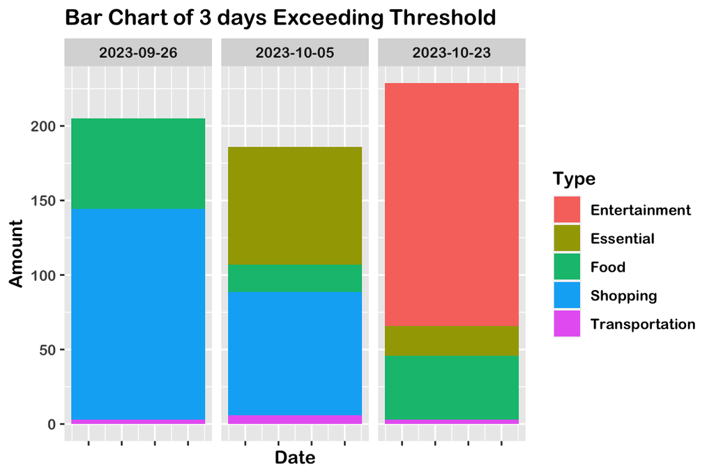

```r
dates_to_filter <- as.Date(c("2023-09-26", "2023-10-05", "2023-10-23"))

filtered_df <- df %>%
  filter(Date %in% dates_to_filter)

plot <- ggplot(filtered_df, aes(Date, Amount, fill = Type)) +
  geom_col() +
  labs(title = "Bar Chart of 3 days Exceeding Threshold") +
  theme(text = element_text(family = "Arial Rounded MT Bold"), axis.text.x = element_blank()) +
  facet_wrap(~Date, scales = "free_x", ncol = 3)

plot
```

in 9/26: the shopping accounts for great proportion of the bar in 10/5: essential and shopping in 10/23: the entertainment accounts for significant part of the bar

```r
# 2023/9/26
filtered_df %>%
  filter(Date == "2023-09-26") %>%
  filter(Type == "Shopping")
```

```
##         Date                                  Payee Amount     Type Subtype
## 1 2023-09-26 AMZN Mktp US*T15PS2C81 Amzn.com/billWA 141.53 Shopping    None
```

```r
# 2023/10/5
filtered_df %>%
  filter(Date == "2023-10-05") %>%
  filter(Type == "Shopping" | Type == "Essential")
```

```
##         Date                                  Payee Amount      Type Subtype
## 1 2023-10-05 AMZN Mktp US*T96K58JM1 Amzn.com/billWA  82.75  Shopping    None
## 2 2023-10-05 AMZN Mktp US*TE11S7LD2 Amzn.com/billWA  79.00 Essential    None
```

```r
# 2023/10/23
filtered_df %>%
  filter(Date == "2023-10-23") %>%
  filter(Type == "Entertainment")
```

```
##         Date                                Payee Amount          Type Subtype
## 1 2023-10-23 PAYPAL *TICKETMASTER 402-935-7733 CA 162.75 Entertainment    None
```

for the 9/26, I bought a guitar which I would like to practice in leisure time and it could be sold upon graduation or I would keep it for a long time

for 10/05, I bought a volleyball to either practice at home or bring it while hanging out with friend. The essential item is running shoes, which I have planned to buy it for running, and it’s also a long term item.

for 10/23, I bought an NBA ticket to fulfill my dream to watch NBA game. It’s not a monthly expense, and I think it’s worth spending to experience the feeling of professional basketball.

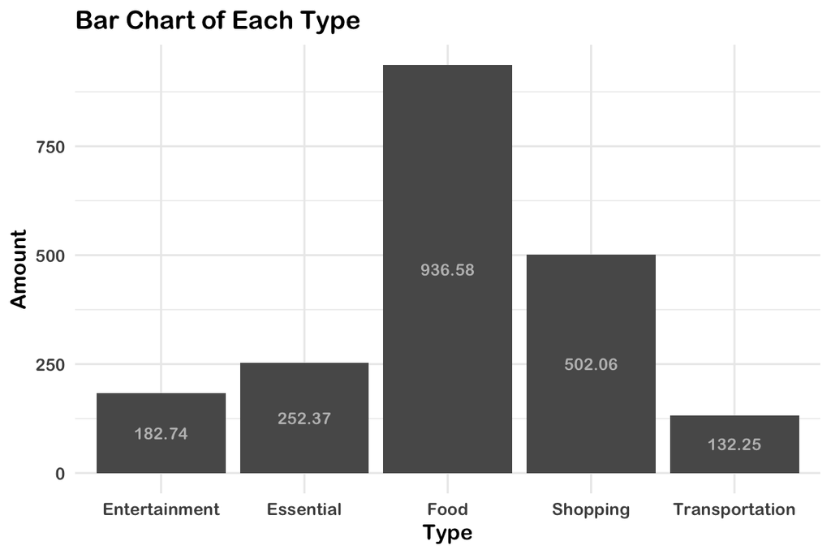

```r
# We can also look data By Type
total_amount <- df %>%
  group_by(Type) %>%
  summarise(Total = sum(Amount))

ggplot() +
  geom_col(data = df, aes(x = Type, y = Amount)) +
  geom_text(data = total_amount, aes(x = Type, y = Total, label = Total),
            position = position_stack(vjust = 0.5), size = 3, color = "grey", family = "Arial Rounded MT Bold") +
  labs(title = "Bar Chart of Each Type") +
  theme_minimal() +
  theme(text = element_text(family = "Arial Rounded MT Bold"))
```

```r
# Bar Charts Type
# ggplot(df, aes(x = Type, y = Amount)) +
#   geom_col() +
#   labs(title = "Bar Chart of Daily Expenses of Each Type") +
#   theme(text = element_text(family = "Arial Rounded MT Bold"))
```

the food category has the most amount in this month expense.

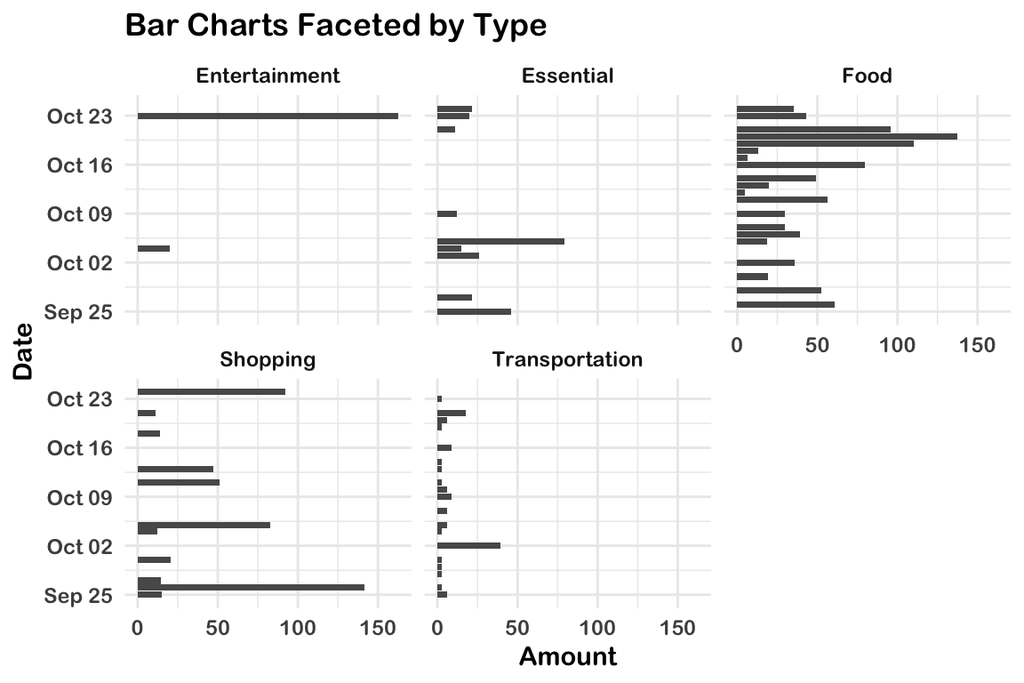

```r
# Bar Charts Faceted by Type
ggplot(df, aes(x = Date, y = Amount)) +
  geom_col() +
  facet_wrap(~Type, scales = "fixed") +
  theme_minimal() +
  labs(title = "Bar Charts Faceted by Type",
       x = "Date",
       y = "Amount")+
  coord_flip() +
  theme(text = element_text(family = "Arial Rounded MT Bold"))
```

in the late September and late Octobor, the shopping and entertainment have the higher amount, and the detailed item has explained in the previous charts.

in the food type, there are two bars over $100 dollars in the mid-Oct. Let’s look at what happened in those days.

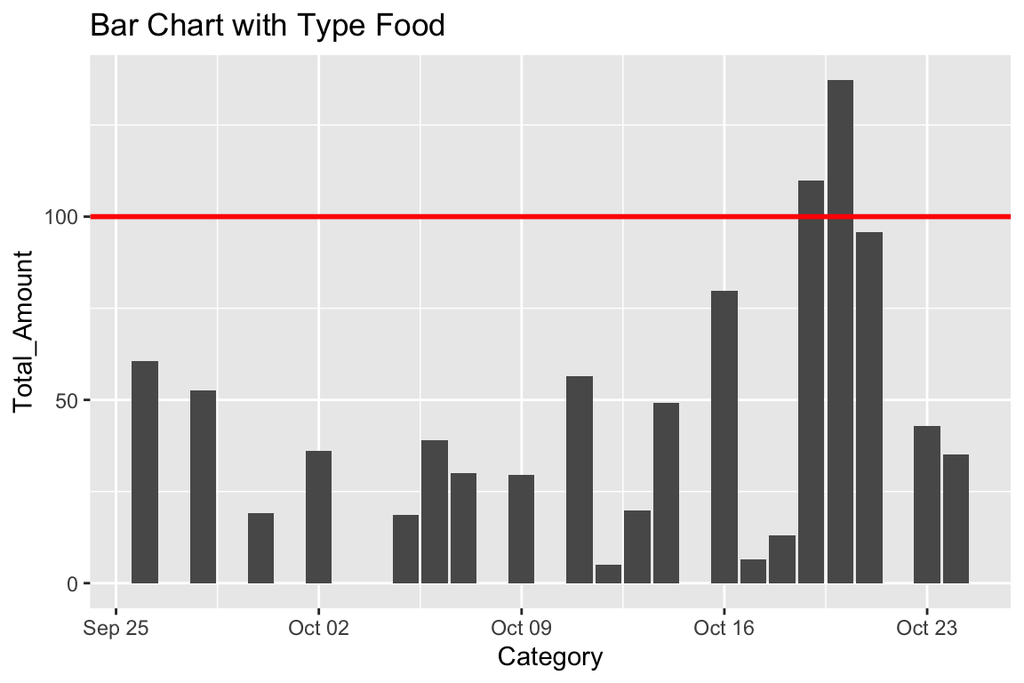

```r
df_food <- df %>%
  filter(Type == "Food") %>%
  group_by(Date) %>%
  summarise(Total_Amount = sum(Amount))


ggplot(df_food, aes(x = Date, y = Total_Amount)) +
  geom_col()+
  geom_hline(yintercept = 100, linetype = "solid", color = "red", size = 1) +
  labs(title = "Bar Chart with Type Food", x = "Category", y = "Total_Amount")
```

```r
# 2023-10-19 food expense
df %>%
  filter(Type == "Food") %>%
  filter(Date == "2023-10-19")
```

```
##         Date                                Payee Amount Type Subtype
## 1 2023-10-19 SQ *BEN & JERRY'S 104TH &New York NY   7.75 Food Outside
## 2 2023-10-19          SQ *SHAKE SHACK New York NY  33.06 Food Outside
## 3 2023-10-19                   H MART NEW YORK NY  42.86 Food    Cook
## 4 2023-10-19          SQ *MAMA'S TOO! New York NY  18.25 Food Outside
## 5 2023-10-19          SQ *MAMA'S TOO! New York NY   8.00 Food Outside
```

```r
# 2023-10-20 food expense
df %>%
  filter(Type == "Food") %>%
  filter(Date == "2023-10-20")
```

```
##         Date                                 Payee Amount Type Subtype
## 1 2023-10-20             Atlas Kitchen new york NY  17.00 Food Outside
## 2 2023-10-20               FIVE SENSES NEW YORK NY  86.87 Food Outside
## 3 2023-10-20 LS JACQUES TORRES CHO 171-88751269 NY  14.37 Food Outside
## 4 2023-10-20  SQ *OLD FULTON HILI COFFEBrooklyn NY  19.00 Food Outside
```

10/19: the expense on Oct.19 contain two large transactions, Shake Shack and Hmart, Both of them haven’t split the amount with friends. As a result, the expense would be divied by 4.

10/20: the expense in Five Senses restaurant is $86.87, but actually I also haven’t split the check with friends. So, the amount should be lower

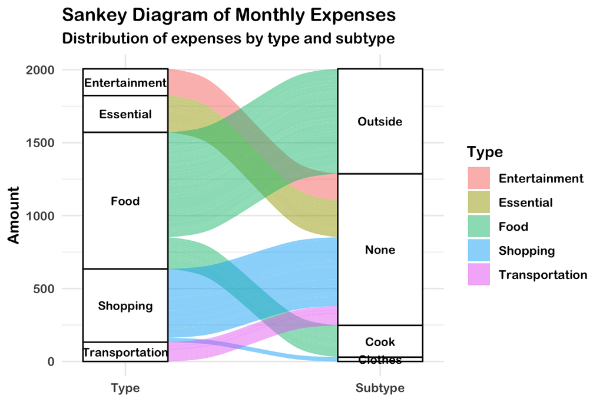

```r
# By subtype

# Sankey Diagram
ggplot(data = df, aes(axis1 = Type, axis2 = fct_rev(Subtype), y = Amount)) +
  geom_alluvium(aes(fill = Type))+
  scale_x_discrete(limits = c("Type", "Subtype"), expand = c(.2, .05)) +
  geom_stratum() +
  geom_text(stat = "stratum",
            aes(label = after_stat(stratum)),
            size = 3,
            family = "Arial Rounded MT Bold") +
  labs(title = "Sankey Diagram of Monthly Expenses",
       subtitle = "Distribution of expenses by type and subtype") +
  theme_minimal() +
  theme(text = element_text(family = "Arial Rounded MT Bold"))
```

based on the plot, it looks approximately 1/4 of food expense is cook

a little informative, maybe I need to add more subtype in the data to deepen understanding of the expense.

```r
# stack bar chart of the food
summary_data <- df %>%
  filter(Subtype == "Outside" | Subtype == "Cook") %>%
  group_by(Subtype) %>%
  summarise(Total_Amount = sum(Amount))
summary_data
```

```
## # A tibble: 2 × 2
##   Subtype Total_Amount
##   <chr>          <dbl>
## 1 Cook            217.
## 2 Outside         719.
```

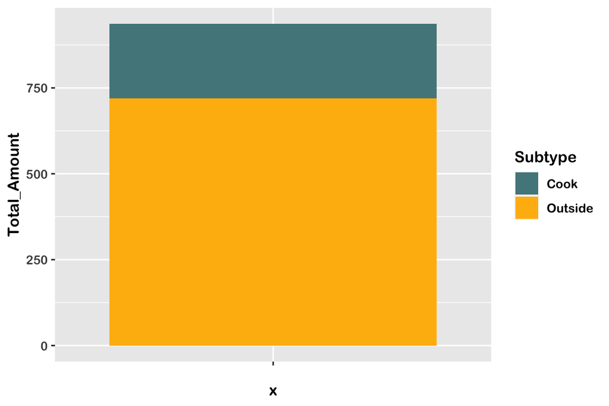

```r
ggplot(summary_data, aes(x = "", y = Total_Amount, fill = Subtype)) +
  geom_bar(stat = "identity", position = 'stack') +
  scale_fill_manual(values = c("Cook" = "cadetblue4", "Outside" = "darkgoldenrod1")) +
  theme(text = element_text(family = "Arial Rounded MT Bold"))
```

```r
  labs(
    title = "Stacked Bar Plot of Total Amount by Subtype",
    y = "Total Amount",
    x = "Type Food",
    fill = "Subtype"
  )
```

```
## $y
## [1] "Total Amount"
##
## $x
## [1] "Type Food"
##
## $fill
## [1] "Subtype"
##
## $title
## [1] "Stacked Bar Plot of Total Amount by Subtype"
##
## attr(,"class")
## [1] "labels"
```

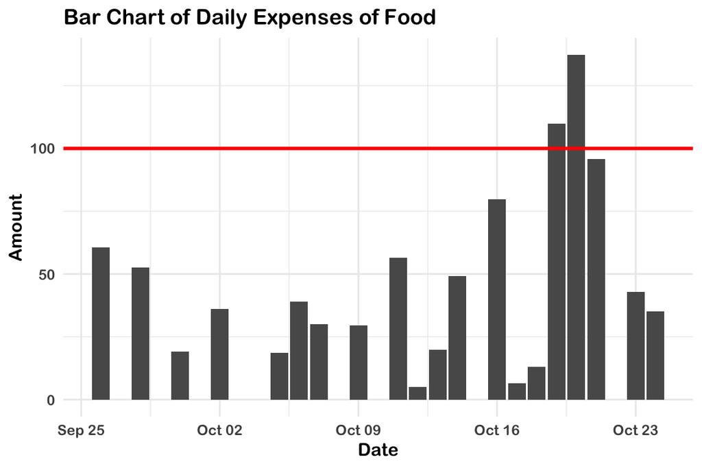

```r
# how many days I eat outside
df %>%
  filter(Type == "Food") %>%
  ggplot(aes(x = Date, y = Amount)) +
  geom_col() +
  labs(title = "Bar Chart of Daily Expenses of Food") +
  geom_hline(yintercept = 100, linetype = "solid", color = "red", size = 1) +
  theme_minimal() +
  theme(text = element_text(family = "Arial Rounded MT Bold"))
```

17 days eat outside means i have 13 days cook by ourself. Approximately, a person only spend $16.7 per day on meal, and I think it’s really economical.

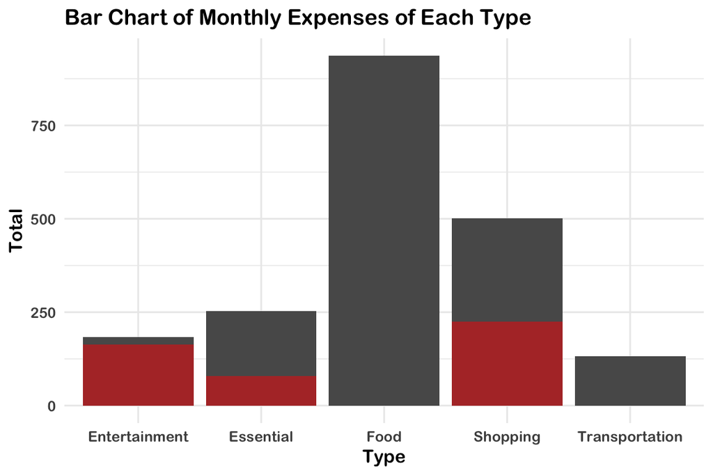

```r
HighlightProportion = c(162.75/182.74,79/252.37,0,224.08/502.06,0)
ggplot() +
  geom_col(data = total_amount, aes(x = Type, y = Total)) +
  geom_col(data = total_amount %>% mutate(HighlightAmount = Total * HighlightProportion),
           aes(x = Type, y = HighlightAmount), fill = "red", alpha = 0.5) +
  # geom_text(data = total_amount, aes(x = Type, y = Total, label = Total),
  #           position = position_stack(vjust = 0.5), size = 3, color = "grey", family = "Arial Rounded MT Bold") +
  labs(title = "Bar Chart of Monthly Expenses of Each Type") +
  theme_minimal() +
  theme(text = element_text(family = "Arial Rounded MT Bold"))
```

All in all, I think I could set my budget to $1500, especially after subtracting those long-term investment items, or one-time entertainment.